# BilgisayarP_DönemÖdevi

```python
import pandas as pd
import numpy as np
import matplotlib.pyplot as plt
import plotly.express as px
import plotly.io as pio
import seaborn as sns

pio.renderers.default = "notebook"

sns.set_style("whitegrid")
plt.rcParams["figure.figsize"] = (10, 5)
```

```python
import os
import pandas as pd
import numpy as np

os.makedirs("data", exist_ok=True)

np.random.seed(42)
satir_sayisi = 350
kategoriler = ["Elektronik", "Giyim", "Ev & Yaşam", "Kozmetik", "Kitap"]

veri = {
    "musteri_id": range(1001, 1001 + satir_sayisi),
    "yas": np.random.randint(18, 65, size=satir_sayisi),
    "kategori": np.random.choice(kategoriler, size=satir_sayisi, p=[0.3, 0.25, 0.2, 0.15, 0.1]),
    "fiyat": np.round(np.random.uniform(100, 4000, size=satir_sayisi), 2),
    "miktar": np.random.randint(1, 6, size=satir_sayisi)
}

df_taslak = pd.DataFrame(veri)
df_taslak["harcama"] = df_taslak["fiyat"] * df_taslak["miktar"]

df_taslak.loc[df_taslak.sample(n=5).index, "yas"] = np.nan

df_taslak.to_csv("data/veri_seti.csv", index=False, encoding="utf-8")
print(" 'data' klasörü ve 350 satırlık 'veri_seti.csv' başarıyla oluşturuldu!")
```

```
 'data' klasörü ve 350 satırlık 'veri_seti.csv' başarıyla oluşturuldu!
```

```python
dosya_yolu = "data/veri_seti.csv"

try:
    df = pd.read_csv(dosya_yolu, encoding="utf-8")
    print(" Veri seti başarıyla yüklendi!")

    print(f"Boyut Bilgisi: {df.shape[0]} satır, {df.shape[1]} sütun\n")

    print("--- Verinin İlk 5 Satırı ---")
    display(df.head())

    print("\n--- Eksik Değer Kontrolü ---")
    print(df.isnull().sum())

except FileNotFoundError:
    print(f" Hata: '{dosya_yolu}' konumunda dosya bulunamadı!")
    print("Lütfen projenizin içinde 'data' adında bir klasör olduğundan ve içinde veri setinizin olduğundan emin olun.")
```

```
 Veri seti başarıyla yüklendi!
Boyut Bilgisi: 350 satır, 6 sütun

--- Verinin İlk 5 Satırı ---
```

|  | musteri_id | yas | kategori | fiyat | miktar | harcama |
| --- | --- | --- | --- | --- | --- | --- |
| 0 | 1001 | 56.0 | Kozmetik | 790.34 | 2 | 1580.68 |
| 1 | 1002 | 46.0 | Giyim | 445.94 | 5 | 2229.70 |
| 2 | 1003 | 32.0 | Elektronik | 570.48 | 1 | 570.48 |
| 3 | 1004 | 60.0 | Ev & Yaşam | 1897.04 | 2 | 3794.08 |
| 4 | 1005 | 25.0 | Kitap | 904.70 | 5 | 4523.50 |

```
--- Eksik Değer Kontrolü ---
musteri_id    0
yas           5
kategori      0
fiyat         0
miktar        0
harcama       0
dtype: int64
```

```python
print(" Sayısal Değişkenlerin Tanımsal İstatistik Özeti:")
display(df.describe())

print("\n Kategori Bazlı Dağılım (Müşteri Frekansı ve Yüzdesi):")
frekans = df["kategori"].value_counts()
yuzde = df["kategori"].value_counts(normalize=True) * 100
display(pd.DataFrame({"Frekans": frekans, "Yüzde (%)": yuzde}))

print("\n Ürün Kategorilerine Göre Harcama Ortalama ve Standart Sapmaları:")
grup_ozet = df.groupby("kategori").agg({"harcama": ["mean", "std"], "miktar": ["sum", "count"]})
display(grup_ozet)

print("\n Sayısal Değişkenler Arası Doğrusal İlişki (Korelasyon):")
korelasyon = df.select_dtypes(include=np.number).corr()
display(korelasyon)
```

```
 Sayısal Değişkenlerin Tanımsal İstatistik Özeti:
```

|  | musteri_id | yas | fiyat | miktar | harcama |
| --- | --- | --- | --- | --- | --- |
| count | 350.000000 | 345.000000 | 350.000000 | 350.000000 | 350.000000 |
| mean | 1175.500000 | 41.214493 | 1950.525686 | 2.991429 | 5819.392257 |
| std | 101.180532 | 13.474796 | 1107.100665 | 1.419244 | 4626.684959 |
| min | 1001.000000 | 18.000000 | 118.060000 | 1.000000 | 203.480000 |
| 25% | 1088.250000 | 30.000000 | 934.910000 | 2.000000 | 2184.112500 |
| 50% | 1175.500000 | 42.000000 | 1899.430000 | 3.000000 | 4482.330000 |
| 75% | 1262.750000 | 52.000000 | 2904.177500 | 4.000000 | 8054.595000 |
| max | 1350.000000 | 64.000000 | 3987.810000 | 5.000000 | 19704.400000 |

```
 Kategori Bazlı Dağılım (Müşteri Frekansı ve Yüzdesi):
```

| kategori | Frekans | Yüzde (%) |
| --- | --- | --- |
| Elektronik | 100 | 28.571429 |
| Giyim | 83 | 23.714286 |
| Ev & Yaşam | 69 | 19.714286 |
| Kozmetik | 56 | 16.000000 |
| Kitap | 42 | 12.000000 |

```
 Ürün Kategorilerine Göre Harcama Ortalama ve Standart Sapmaları:
```

| kategori | harcama mean | harcama std | miktar sum | miktar count |
| --- | --- | --- | --- | --- |
| Elektronik | 5680.287900 | 4425.262341 | 288 | 100 |
| Ev & Yaşam | 5638.278986 | 4819.855769 | 203 | 69 |
| Giyim | 6251.065301 | 4764.577505 | 272 | 83 |
| Kitap | 6200.237857 | 4372.904454 | 126 | 42 |
| Kozmetik | 5365.515000 | 4804.435632 | 158 | 56 |

```
 Sayısal Değişkenler Arası Doğrusal İlişki (Korelasyon):
```

|  | musteri_id | yas | fiyat | miktar | harcama |
| --- | --- | --- | --- | --- | --- |
| musteri_id | 1.000000 | 0.039835 | 0.025460 | 0.065837 | 0.045866 |
| yas | 0.039835 | 1.000000 | -0.019859 | -0.000914 | 0.019872 |
| fiyat | 0.025460 | -0.019859 | 1.000000 | -0.009871 | 0.709504 |
| miktar | 0.065837 | -0.000914 | -0.009871 | 1.000000 | 0.605272 |
| harcama | 0.045866 | 0.019872 | 0.709504 | 0.605272 | 1.000000 |

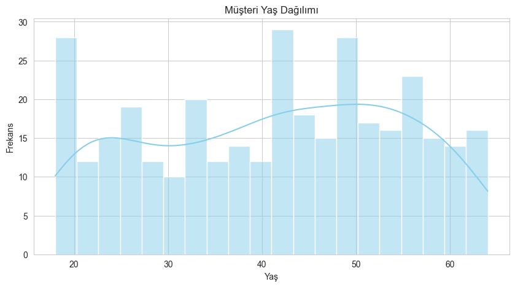

```python
sns.histplot(df["yas"], bins=20, kde=True, color="skyblue")
plt.title("Müşteri Yaş Dağılımı")
plt.xlabel("Yaş")
plt.ylabel("Frekans")
plt.show()
```

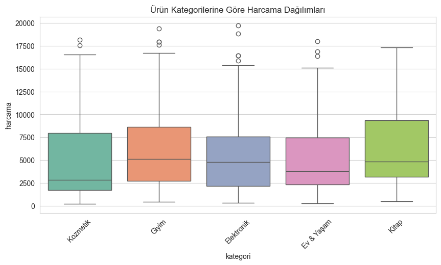

```python
sns.boxplot(data=df, x="kategori", y="harcama", hue="kategori", palette="Set2", legend=False)
plt.title("Ürün Kategorilerine Göre Harcama Dağılımları")
plt.xticks(rotation=45)
plt.show()
```

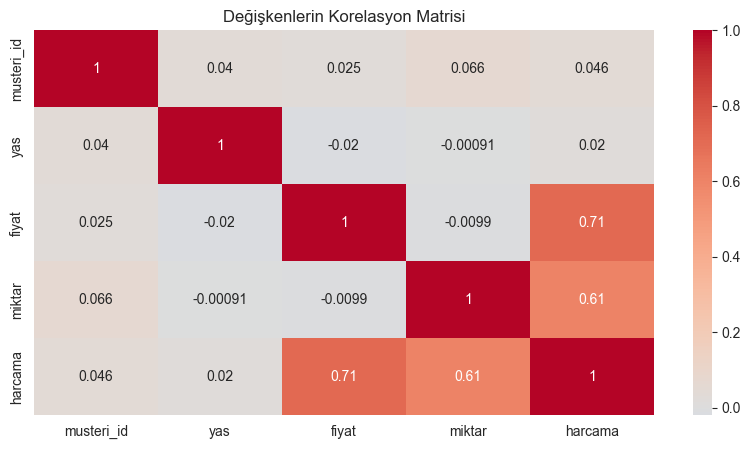

```python
sns.heatmap(df.select_dtypes(include=np.number).corr(), annot=True, cmap="coolwarm", center=0)
plt.title("Değişkenlerin Korelasyon Matrisi")
plt.show()
```

Grafik 3 Yorumu: Korelasyon ısı haritası (Heatmap) incelendiğinde, toplam harcama tutarı ile ürün fiyatı arasında güçlü ve pozitif yönlü (0.71) bir ilişki olduğu görülmektedir. Benzer şekilde, satın alınan ürün miktarı ile harcama tutarı arasında da pozitif yönlü (0.61) belirgin bir bağ vardır. Buna karşın, müşteri yaşının harcama sepeti üzerinde doğrusal anlamda istatistiksel bir etkisi saptanmamıştır.

```python
fig1 = px.bar(df.groupby("kategori")["miktar"].sum().reset_index(),
            x="kategori", y="miktar", title="Kategorilere Göre Toplam Satılan Ürün Adedi",
            labels={"miktar": "Toplam Satış Adedi", "kategori": "Ürün Kategorisi"},
            color="kategori")
fig1.show()
```

[interactive chart not shown]

Grafik 4 Yorumu: Plotly ile çizdirilen etkileşimli çubuk grafik incelendiğinde, adet bazında en çok satış yapılan kategorinin Elektronik (~285 adet) ve hemen ardından Giyim (~270 adet) olduğu görülmektedir. Mağazanın adet bazında en az satış gerçekleştirdiği kategori ise Kitap (~125 adet) olarak kayıtlara geçmiştir.

```python
fig2 = px.scatter(df, x="fiyat", y="harcama", color="kategori", size="miktar",
                title="Ürün Fiyatı ve Toplam Harcama İlişkisi (Miktar Boyutlu)",
                labels={"fiyat": "Ürün Fiyatı (TL)", "harcama": "Toplam Sepet Harcaması (TL)"})
fig2.show()
```

[interactive chart not shown]

Grafik 5 Yorumu: Saçılım grafiği (Scatter plot) incelendiğinde, ürün fiyatı arttıkça toplam sepet harcama tutarının da doğrusal bir şekilde yükseldiği net bir şekilde gözlenmektedir. Grafik üzerindeki balonların büyüklüğü tek seferde satın alınan ürün adedini (miktarını) temsil etmekte olup, yüksek bütçeli harcamaların büyük oranda hem fiyatı yüksek ürünlerden hem de yüksek adetli siparişlerden kaynaklandığı doğrulanmaktadır.

## Bulgular ve Sonuçlar

Bu veri analizi çalışmasından elde edilen 3 temel stratejik içgörü şu şekildedir:

1. **Kategori Performansı:** Mağazanın hem müşteri frekansı (%28.57) hem de satış adeti bakımından en güçlü kası Elektronik kategorisidir.
2. **Sepet Genişletme Stratejisi:** İstatistiksel korelasyon matrisi ve saçılım grafiği, toplam harcamanın doğrudan ürün fiyatı ve miktarla olan güçlü doğrusal bağını (0.71 ve 0.61) kanıtlamaktadır. Müşterileri daha çok adet almaya teşvik edecek çoklu ürün promosyonları veya sepet indirimleri ciroyu doğrudan artıracaktır.
3. **Potansiyel Alanlar:** Kitap kategorisi ciro ve adet bazında en düşük performansı göstermektedir. Bu kategoriye özel sadakat programları veya sepet tamamlama önerileri kurgulanması ciro dengesi açısından önem arz etmektedir.